# Analysis for paper on cultural evolution of statistical structure

```r
library(reticulate)
```

```python
reticulate::repl_python()
import numpy as np
import pandas as pd
import seaborn as sns
import matplotlib.pyplot as plt
from collections import defaultdict
from math import log, log2
```

```python
sns.set_theme()
sns.set_context("notebook")
plt.tight_layout(pad=3)
```

```python
data = pd.read_csv("simon_game_data.csv")
data["sentence_number"] = [str(x) for x in list(range(60))*66]
data["sentence_id"] = data["chain"] + data["sentence_number"]
data
```

```
      generation        string     error chain sentence_number sentence_id
0              0  RGRYYGGBRBYB  0.500000     B               0          B0
1              0  YRGRYBBGGYRB  0.461538     B               1          B1
2              0  BBRRGYRYGYGB  0.250000     B               2          B2
3              0  BGYBGRYRYBRG  0.250000     B               3          B3
4              0  GBRYRBBRGYGY  0.384615     B               4          B4
...          ...           ...       ...   ...             ...         ...
3955          10   RYRYRBGRBGR       NaN     A              55         A55
3956          10    RYRYRYGRBG       NaN     A              56         A56
3957          10    RYRYRBBRRY       NaN     A              57         A57
3958          10  GYGBGYBRGYBR       NaN     A              58         A58
3959          10    GRGRYBYBRG       NaN     A              59         A59

[3960 rows x 6 columns]
```

## Check for decrease in error (hallmark of iterated learning)

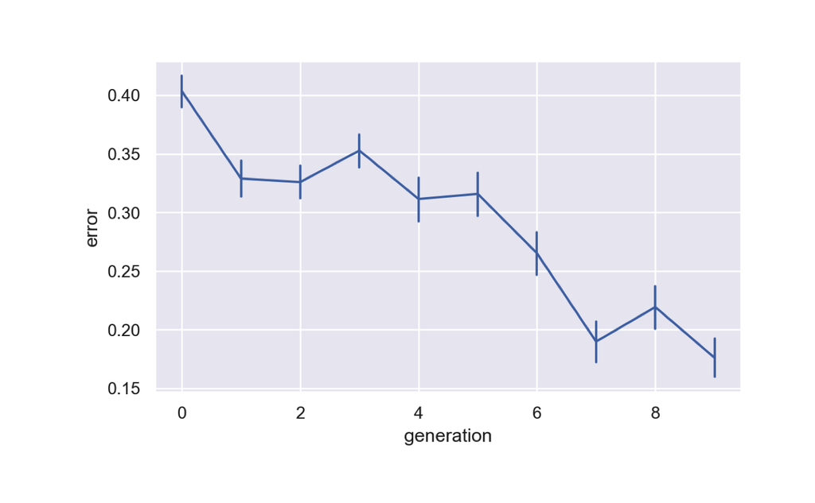

```python
sns.lineplot(data, x="generation", y="error", err_style="bars")
plt.tight_layout(pad=3.5)
plt.show()
plt.savefig("error.png")
plt.clf()
```

Very clear decrease in error.

```r
quit
library(lme4)
library(lmerTest)
model <- lmer(data=py$data, error ~ generation + (1+generation|chain) + (1|sentence_id))
summary(model)
```

```
Linear mixed model fit by REML. t-tests use Satterthwaite's method ['lmerModLmerTest']
Formula: error ~ generation + (1 + generation | chain) + (1 | sentence_id)
   Data: py$data

REML criterion at convergence: -3225.7

Scaled residuals:
    Min      1Q  Median      3Q     Max
-2.6461 -0.7287  0.0005  0.6635  3.8275

Random effects:
 Groups      Name        Variance  Std.Dev. Corr
 sentence_id (Intercept) 1.020e-03 0.031930
 chain       (Intercept) 2.061e-03 0.045400
             generation  5.626e-05 0.007501 -0.49
 Residual                2.271e-02 0.150705
Number of obs: 3600, groups:  sentence_id, 360; chain, 6

Fixed effects:
             Estimate Std. Error        df t value Pr(>|t|)
(Intercept)  0.391312   0.019187  5.000040  20.394 5.24e-06 ***
generation  -0.022755   0.003185  4.999458  -7.145 0.000834 ***
---
Signif. codes:  0 ‘***’ 0.001 ‘**’ 0.01 ‘*’ 0.05 ‘.’ 0.1 ‘ ’ 1

Correlation of Fixed Effects:
           (Intr)
generation -0.507
```

## Functions to build n-gram entropy and ranked n-gram frequency data frames

These work with either strings, or lists of strings. In the latter case, the relevant unit is the whole word, whereas in the former it is the character. Basically, we use strings if we want to examine, e.g. ngram frequencies of characters. The latter we would normally just use at the n=1 level to look at the ranked frequency distribution of individual words (as opposed to sequences of words)

```python
reticulate::repl_python()
def ngram_table(data, generation, chain, n):
    strings = data[(data["chain"] == chain) & (data["generation"] == generation)]["string"]
    ngram_counts = defaultdict(int)
    for s in strings:
        for i in range(len(s) - (n - 1)):
            ngram = s[i:i+n]
            ngram_counts[str(ngram)] = ngram_counts[str(ngram)] + 1
    return ngram_counts

def ngram_entropy(ngram_counts):
    total_count = float(sum(ngram_counts.values()))
    entropy = 0.
    for count in ngram_counts.values():
        entropy -= count/total_count * log2(count/total_count)
    return entropy


def ngram_entropies(data, n):
    generations = list(set(data["generation"]))
    chains = list(set(data["chain"]))
    data_dict = {'generation':[], 'chain':[], 'ngram_entropy':[], 'ngram_count':[], 'error':[]}
    for c in chains:
        for g in generations:
            data_dict['generation'].append(g)
            data_dict['chain'].append(c)
            data_dict['ngram_entropy'].append(ngram_entropy(ngram_table(data, g, c, n)))
            data_dict['ngram_count'].append(sum(ngram_table(data, g, c, n).values()))
            data_dict['error'].append( data[(data["generation"]==g)&(data["chain"]==c)]["error"].mean())
    return pd.DataFrame.from_dict(data_dict)

def ranked_ngram_frequencies(data, n):
    generations = list(set(data["generation"]))
    chains = list(set(data["chain"]))
    data_dict = {'generation':[], 'chain':[], 'rank':[], 'count':[], 'log_rank':[], 'log_count':[]}
    for c in chains:
        for g in generations:
            bg = sorted(list(ngram_table(data, g, c, n).values()), reverse=True)
            for i in range(len(bg)):
                data_dict['generation'].append(g)
                data_dict['chain'].append(c)
                data_dict['rank'].append(i)
                data_dict['count'].append(bg[i])
                data_dict['log_rank'].append(log(i + 1))
                data_dict['log_count'].append(log(bg[i]))
    return pd.DataFrame.from_dict(data_dict)
```

## Functions to build a data frame with TPs instead of sequences

This is mainly to process characters into TPs between characters, for using to segment the strings into word sets. If n=2, then this is done with bigrams essentially. So, it’s looking at the probability of a character based on the previous character. If n=3, then it is looking at the probability of a character based on the previous two characters. Note that this means the length of the TPs is the string length minus n - 1.

```python
def transition_data(data, generation, chain, n):
    ngrams = ngram_table(data, generation, chain, n)
    ngrams_sum = sum(ngrams.values())
    smaller_grams = ngram_table(data, generation, chain, n - 1)
    smaller_grams_sum = sum(smaller_grams.values())
    strings = data[(data["chain"] == chain) & (data["generation"] == generation)]["string"]
    transitions_list = []
    for string in strings:
        transitions = []
        for i in range(len(string) - (n - 1)):
            transitions.append((ngrams[string[i:i+n]]/ngrams_sum) / (smaller_grams[string[i:i+(n-1)]]/smaller_grams_sum))
        transitions_list.append(transitions)
    return transitions_list

def transition_data_frame(data, n):
    generations = list(set(data["generation"]))
    chains = list(set(data["chain"]))
    data_dict = {'generation':[], 'chain':[], 'sentence_number':[], 'position':[], 'transition_probability':[]}
    for c in chains:
        for g in generations:
            td = transition_data(data, g, c, n)
            for i in range(len(td)):
                for j in range(len(td[i])):
                    data_dict['generation'].append(g)
                    data_dict['chain'].append(c)
                    data_dict['sentence_number'].append(i)
                    data_dict['position'].append(j)
                    data_dict['transition_probability'].append(td[i][j])
    return pd.DataFrame.from_dict(data_dict)
```

## Cut up the sequences based on transitional probabilities and some chosen cutoff point.

Now we can slice up the original strings of characters based on any particularly low transitional probabilities that we find, which indicate word boundaries. We’re looking for dips in the TPs such that a TP at position n is lower by some cutoff ration than the TP at position n-1.

The raios_df function creates a new data frame with the ratios between TPs at n and TPs and n+1. The idea is to be able to see the distribution of TP ratios in the random initial data and use this as a principled way of deciding where the cutoff should be for slicing up the sequences.

```python
def cut_sequences(data, td, generation, chain, n, cutoff):
    strings = list(data[(data["chain"] == chain) & (data["generation"] == generation)]["string"])
    transitions = td[(td["chain"] == chain) & (td["generation"] == generation)]
    sentences = []
    for i in range(len(strings)):
        ts = list(transitions[transitions["sentence_number"] == i]["transition_probability"])
        words = []
        word = str(strings[i])[0:(n-1)]
        for j in range(len(ts)):
            if ts[j] < cutoff:
                words.append(word)
                word = ''
            word += str(strings[i])[j+(n-1)]
        words.append(word)
        sentences.append(words)
    return sentences


def get_distribution_of_pairs_of_TPs(data, td, generation, chain, n):
    ratios = []
    strings = list(data[(data["chain"] == chain) & (data["generation"] == generation)]["string"])
    transitions = td[(td["chain"] == chain) & (td["generation"] == generation)]
    for i in range(len(strings)):
        ts = list(transitions[transitions["sentence_number"] == i]["transition_probability"])
        last_tp = ts[0]
        for j in range(len(ts)-1):
            ratios.append(ts[j+1]/last_tp)
    return ratios

def ratios_df(data, td, n):
    generations = list(set(data["generation"]))
    chains = list(set(data["chain"]))
    data_dict = {'generation':[], 'chain':[], 'ratio':[]}
    for c in chains:
        for g in generations:
            ratios=get_distribution_of_pairs_of_TPs(data, td, g, c, n)
            for r in ratios:
                data_dict['generation'].append(g)
                data_dict['chain'].append(c)
                data_dict['ratio'].append(r)
    return pd.DataFrame.from_dict(data_dict)

def cut_sequences_sliding(data, td, generation, chain, n, cutoff_ratio):
    strings = list(data[(data["chain"] == chain) & (data["generation"] == generation)]["string"])
    errors = list(data[(data["chain"] == chain) & (data["generation"] == generation)]["error"])
    transitions = td[(td["chain"] == chain) & (td["generation"] == generation)]
    sentences = []
    word_lengths = {}
    within_TPs = []
    across_TPs = []

    for i in range(len(strings)):
        ts = list(transitions[transitions["sentence_number"] == i]["transition_probability"])
        words = []
        word = str(strings[i])[0:(n-1)]
        last_tp = 0
        for j in range(len(ts)):
            if ts[j] < last_tp * cutoff_ratio:
                words.append(word)
                word_lengths[word]=len(word)
                word = ''
                across_TPs.append(ts[j])
            else:
                within_TPs.append(ts[j])
            word += str(strings[i])[j+(n-1)]
            last_tp = ts[j]
        words.append(word)
        word_lengths[word]=len(word)
        sentences.append((words,errors[i]))
    return sentences, word_lengths.values(), within_TPs, across_TPs
```

## Make a new data frame with words instead of characters

First step is to build the transition probabilities

```python
td = transition_data_frame(data, 3)
```

```python
r_df = ratios_df(data, td, 3)
```

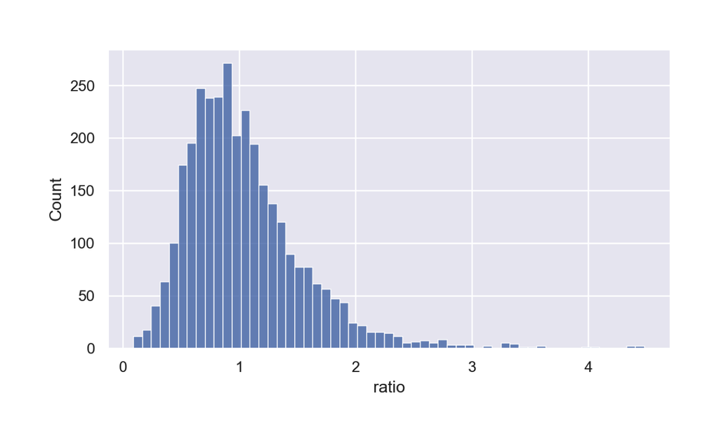

```python
sns.histplot(r_df[r_df["generation"]==0]["ratio"])
plt.tight_layout(pad=3)
plt.show()
plt.clf()
```

```python
def percentile(data_points, alpha):
    return sorted(list(data_points))[int(len(data_points)*alpha)]
```

Now build a new data frame with the cut up sequences of words in it based on the five percent lowest TP-ratios in the generation 0 data.

**Remember that the n parameter here needs to match the one that build the transition probabilities!**

```python
def build_new_data(data, td, n, cutoff_ratio):
    data_dict={'generation':[], 'chain':[], 'string':[], 'length':[], 'error':[]}
    data_lengths_dict={'generation':[], 'chain':[], 'word_length':[]}
    data_within_TPs_dict={'generation':[], 'chain':[], 'transition_probability':[], 'type':[]}
    data_across_TPs_dict={'generation':[], 'chain':[], 'transition_probability':[], 'type':[]}
    for g in set(data["generation"]):
        for c in set(data["chain"]):
            new_strings, word_lengths, within_TPs, across_TPs = cut_sequences_sliding(data, td, g, c, n, cutoff_ratio)
            for s, e in new_strings:
                data_dict['generation'].append(g)
                data_dict['chain'].append(c)
                data_dict['string'].append(s)
                data_dict['length'].append(len(s))
                data_dict['error'].append(e)
            for l in word_lengths:
                data_lengths_dict['generation'].append(g)
                data_lengths_dict['chain'].append(c)
                data_lengths_dict['word_length'].append(l)
            for w in within_TPs:
                data_within_TPs_dict['generation'].append(g)
                data_within_TPs_dict['chain'].append(c)
                data_within_TPs_dict['transition_probability'].append(w)
                data_within_TPs_dict['type'].append('within')
            for a in across_TPs:
                data_across_TPs_dict['generation'].append(g)
                data_across_TPs_dict['chain'].append(c)
                data_across_TPs_dict['transition_probability'].append(a)
                data_across_TPs_dict['type'].append('between')

    return pd.DataFrame.from_dict(data_dict), pd.DataFrame.from_dict(data_lengths_dict), pd.DataFrame.from_dict(data_within_TPs_dict), pd.DataFrame.from_dict(data_across_TPs_dict)
```

```python
five_percent_tail = percentile(r_df[r_df["generation"]==0]["ratio"], 0.05)
print(five_percent_tail)
```

```
0.425
```

```python
new_data, lengths, within_TPs, across_TPs = build_new_data(data, td, 3, five_percent_tail)
```

```python
transition_probabilities = pd.concat([within_TPs, across_TPs])
```

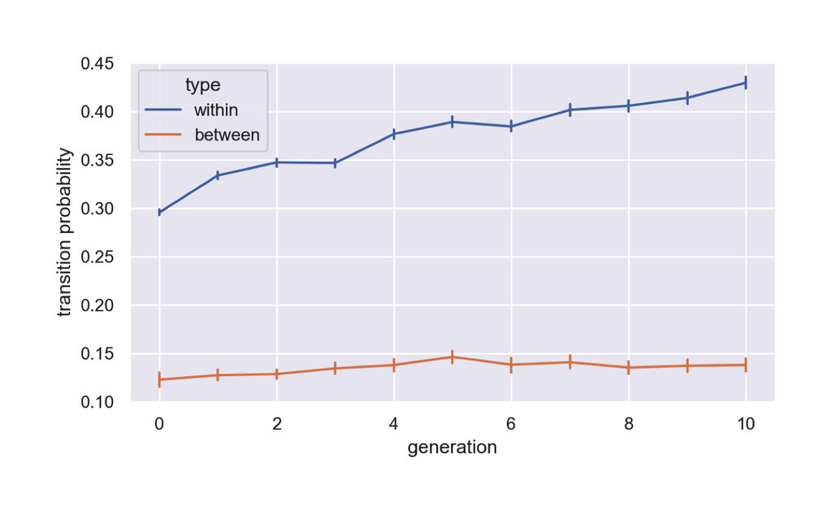

```python
sns.lineplot(transition_probabilities, x="generation", y="transition_probability", hue='type', err_style="bars")
plt.ylabel("transition probability")
plt.tight_layout(pad=3)
plt.show()
plt.savefig("probabilities.png")
plt.clf()
```

```r
quit
library(lme4)
library(lmerTest)

model <- lmer(data=py$transition_probabilities, transition_probability ~ generation * type + (1+generation|chain))

summary(model)
```

```
Linear mixed model fit by REML. t-tests use Satterthwaite's method ['lmerModLmerTest']
Formula: transition_probability ~ generation * type + (1 + generation |      chain)
   Data: py$transition_probabilities

REML criterion at convergence: -44349.8

Scaled residuals:
    Min      1Q  Median      3Q     Max
-3.4070 -0.6844 -0.0625  0.5837  5.9501

Random effects:
 Groups   Name        Variance  Std.Dev. Corr
 chain    (Intercept) 6.907e-04 0.026280
          generation  3.607e-05 0.006006 -0.44
 Residual             1.827e-02 0.135162
Number of obs: 38162, groups:  chain, 6

Fixed effects:
                        Estimate Std. Error         df t value Pr(>|t|)
(Intercept)            1.297e-01  1.165e-02  6.761e+00  11.132 1.36e-05 ***
generation            -1.694e-04  2.560e-03  5.849e+00  -0.066    0.949
typewithin             1.860e-01  4.733e-03  3.815e+04  39.288  < 2e-16 ***
generation:typewithin  1.184e-02  7.731e-04  3.815e+04  15.308  < 2e-16 ***
---
Signif. codes:  0 ‘***’ 0.001 ‘**’ 0.01 ‘*’ 0.05 ‘.’ 0.1 ‘ ’ 1

Correlation of Fixed Effects:
            (Intr) genrtn typwth
generation  -0.482
typewithin  -0.375  0.242
gnrtn:typwt  0.325 -0.275 -0.869
```

The words get shorter over generations.

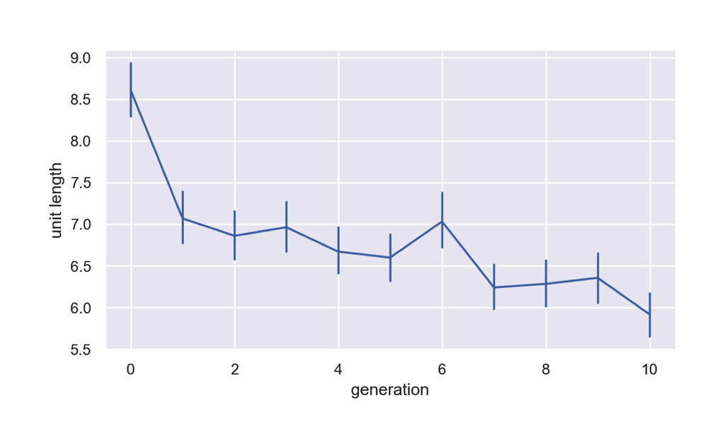

```python
reticulate::repl_python()
sns.lineplot(lengths, x="generation", y="word_length", err_style="bars")
plt.ylabel("unit length")
plt.tight_layout(pad=3)
plt.show()
plt.savefig("lengths.png")
plt.clf()
```

```r
quit
library(lme4)
library(lmerTest)

model <- lmer(data=subset(py$lengths, generation!=0), word_length ~ generation + (1+generation|chain), control=lmerControl(optimizer="bobyqa",
                            optCtrl=list(maxfun=2e5)))

model2 <- lmer(data=py$lengths, word_length ~ generation + (1+generation|chain), control=lmerControl(optimizer="bobyqa",
                            optCtrl=list(maxfun=2e5)))
summary(model)
```

```
Linear mixed model fit by REML. t-tests use Satterthwaite's method ['lmerModLmerTest']
Formula: word_length ~ generation + (1 + generation | chain)
   Data: subset(py$lengths, generation != 0)
Control: lmerControl(optimizer = "bobyqa", optCtrl = list(maxfun = 2e+05))

REML criterion at convergence: 30354.8

Scaled residuals:
    Min      1Q  Median      3Q     Max
-1.8646 -0.7835 -0.1455  0.6937  4.5009

Random effects:
 Groups   Name        Variance Std.Dev. Corr
 chain    (Intercept)  0.22368 0.47294
          generation   0.00844 0.09187  -0.81
 Residual             12.18767 3.49108
Number of obs: 5681, groups:  chain, 6

Fixed effects:
            Estimate Std. Error       df t value Pr(>|t|)
(Intercept)  7.19794    0.21668  5.07793  33.219 3.89e-07 ***
generation  -0.11124    0.04083  5.05852  -2.724   0.0411 *
---
Signif. codes:  0 ‘***’ 0.001 ‘**’ 0.01 ‘*’ 0.05 ‘.’ 0.1 ‘ ’ 1

Correlation of Fixed Effects:
           (Intr)
generation -0.818
```

```r
summary(model2)
```

```
Linear mixed model fit by REML. t-tests use Satterthwaite's method ['lmerModLmerTest']
Formula: word_length ~ generation + (1 + generation | chain)
   Data: py$lengths
Control: lmerControl(optimizer = "bobyqa", optCtrl = list(maxfun = 2e+05))

REML criterion at convergence: 33128.4

Scaled residuals:
    Min      1Q  Median      3Q     Max
-1.9862 -0.8099 -0.1113  0.7454  4.4596

Random effects:
 Groups   Name        Variance Std.Dev. Corr
 chain    (Intercept)  0.15386 0.3922
          generation   0.01036 0.1018   -0.92
 Residual             12.43160 3.5258
Number of obs: 6178, groups:  chain, 6

Fixed effects:
            Estimate Std. Error       df t value Pr(>|t|)
(Intercept)  7.60682    0.18088  5.03379   42.05 1.32e-07 ***
generation  -0.17020    0.04398  5.01235   -3.87   0.0117 *
---
Signif. codes:  0 ‘***’ 0.001 ‘**’ 0.01 ‘*’ 0.05 ‘.’ 0.1 ‘ ’ 1

Correlation of Fixed Effects:
           (Intr)
generation -0.896
```

## Emergence of zipfian distribution

If we plot now the frequency distribution of the cut up words, we see clear zipfian distribution emerging.

```python
reticulate::repl_python()
new_ranked_freq = ranked_ngram_frequencies(new_data, 1)
```

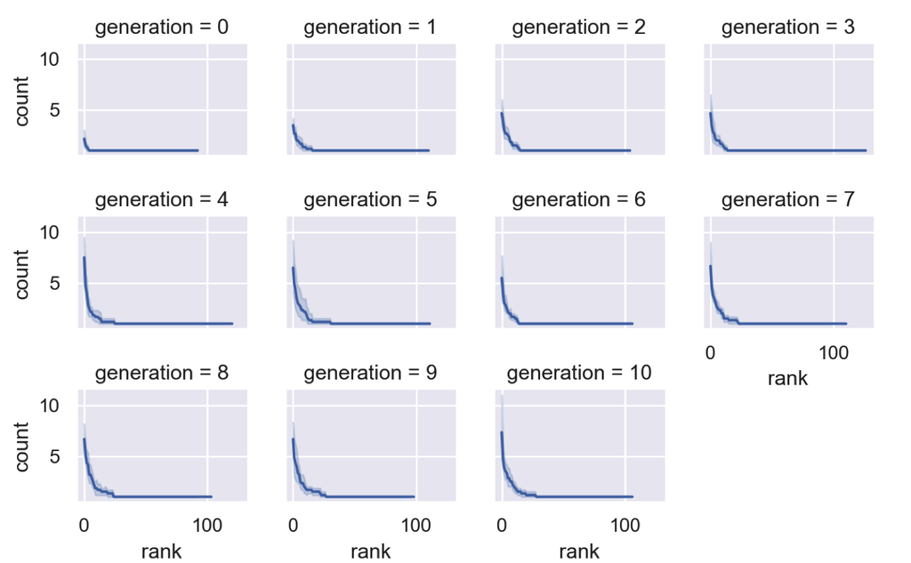

```python
g = sns.FacetGrid(new_ranked_freq, col="generation", col_wrap=4)
g.map_dataframe(sns.lineplot, x="rank", y="count")
plt.tight_layout(pad=3)
plt.show()
plt.savefig("zipf.png")
plt.clf()
```

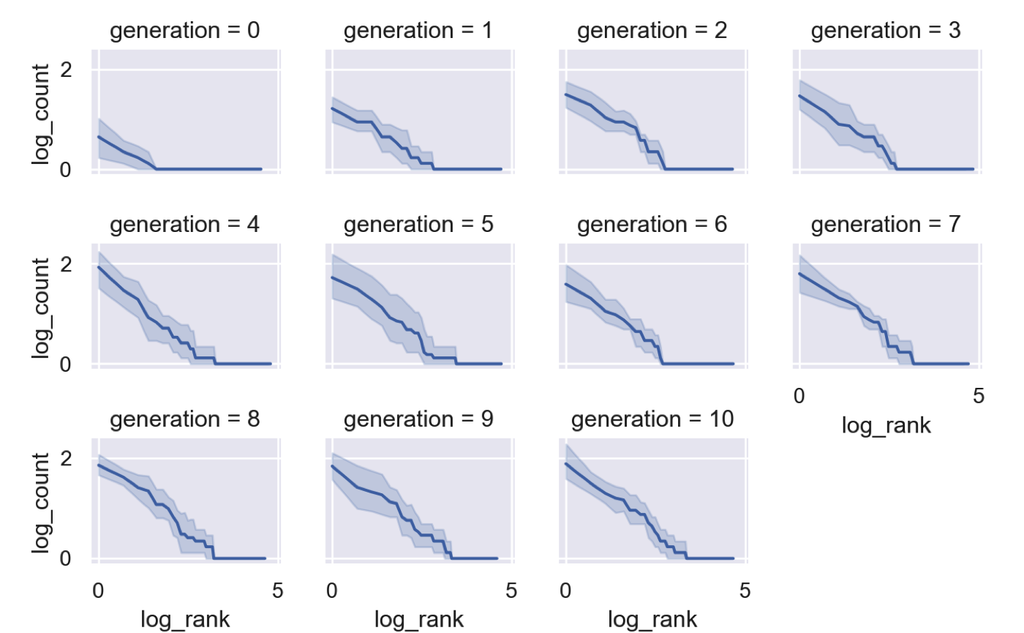

```python
g = sns.FacetGrid(new_ranked_freq, col="generation", col_wrap=4)
g.map_dataframe(sns.lineplot, x="log_rank", y="log_count")
plt.tight_layout(pad=3)
plt.show()
plt.savefig("zipflog.png")
plt.clf()
```

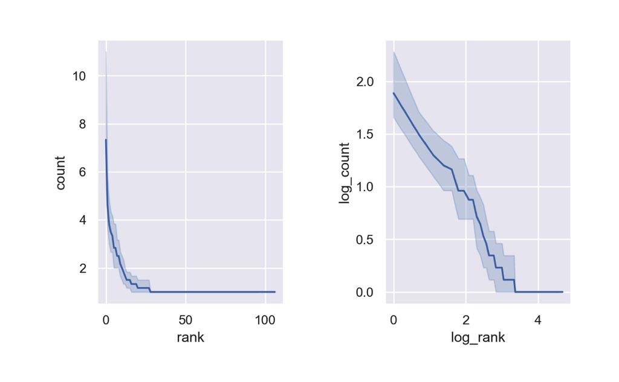

```python
f, axes = plt.subplots(1, 2)

sns.lineplot(new_ranked_freq[new_ranked_freq['generation']==10], x="rank", y="count", ax=axes[0])
sns.lineplot(new_ranked_freq[new_ranked_freq['generation']==10], x="log_rank", y="log_count", ax=axes[1])
plt.tight_layout(pad=3)
plt.show()
plt.savefig("zipffinal.png")
plt.clf()
```

## How well do the frequency distributions fit a power law?

We can calculate the correlation between the log frequency and log rank and plot $R^2$

```python
import scipy.stats

generations = list(set(new_ranked_freq["generation"]))
chains = list(set(new_ranked_freq["chain"]))
data_dict = {'generation':[], 'chain':[], 'correlation_coefficient':[], 'r2':[]}
for c in chains:
    for g in generations[1:]:
        ranks = new_ranked_freq[(new_ranked_freq['generation']==g)&(new_ranked_freq['chain']==c)]['log_rank']
        counts = new_ranked_freq[(new_ranked_freq['generation']==g)&(new_ranked_freq['chain']==c)]['log_count']
        r = scipy.stats.pearsonr(ranks, counts)[0]
        r2 = r ** 2
        data_dict['generation'].append(g)
        data_dict['chain'].append(c)
        data_dict['correlation_coefficient'].append(r)
        data_dict['r2'].append(r2)

correlations = pd.DataFrame.from_dict(data_dict)
```

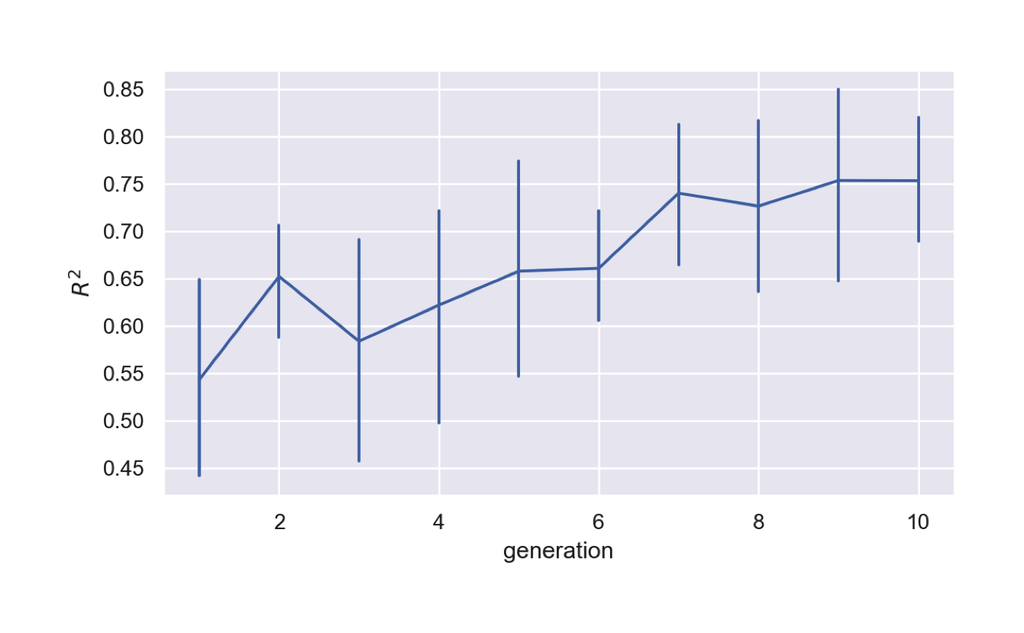

```python
sns.lineplot(correlations, x="generation", y="r2", err_style="bars")
plt.ylabel("$R^2$")
plt.tight_layout(pad=3)
plt.show()
plt.savefig("r2.png")
plt.clf()
```

```r
quit
library(lme4)
library(lmerTest)

model <- lmer(data=py$correlations, r2 ~ generation + (1+generation|chain))

summary(model)
```

```
Linear mixed model fit by REML. t-tests use Satterthwaite's method ['lmerModLmerTest']
Formula: r2 ~ generation + (1 + generation | chain)
   Data: py$correlations

REML criterion at convergence: -91.5

Scaled residuals:
     Min       1Q   Median       3Q      Max
-2.26873 -0.62157 -0.03802  0.62839  1.89536

Random effects:
 Groups   Name        Variance  Std.Dev. Corr
 chain    (Intercept) 0.0146941 0.12122
          generation  0.0001715 0.01310  -0.75
 Residual             0.0075926 0.08714
Number of obs: 60, groups:  chain, 6

Fixed effects:
            Estimate Std. Error       df t value Pr(>|t|)
(Intercept) 0.547046   0.055132 5.000018   9.922 0.000177 ***
generation  0.022218   0.006628 5.000325   3.352 0.020276 *
---
Signif. codes:  0 ‘***’ 0.001 ‘**’ 0.01 ‘*’ 0.05 ‘.’ 0.1 ‘ ’ 1

Correlation of Fixed Effects:
           (Intr)
generation -0.771
```

## Analysis of entropy over words

```python
reticulate::repl_python()
entropies = ngram_entropies(new_data, 1)
```

Entropy (now calculated on words) decreases.

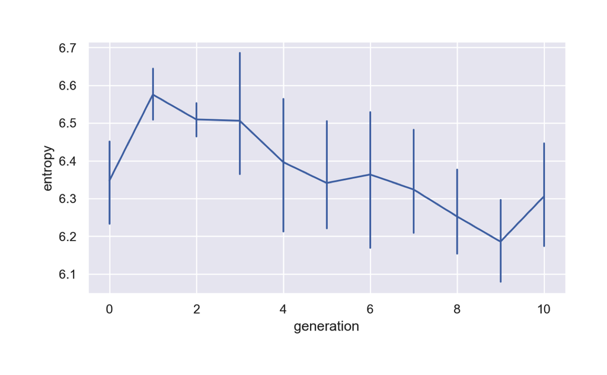

```python
sns.lineplot(entropies, x="generation", y="ngram_entropy", err_style="bars")
plt.ylabel("entropy")
plt.tight_layout(pad=3)
plt.show()
plt.savefig("entropy.png")
plt.clf()
```

Because entropy also depends on number of words we control for this as a fixed effect. (Singular fit with more complex random effect.)

```r
quit
library(lme4)
library(lmerTest)

model <- lmer(data=py$entropies, ngram_entropy ~ generation + ngram_count + (1|chain))
summary(model)
```

```
Linear mixed model fit by REML. t-tests use Satterthwaite's method ['lmerModLmerTest']
Formula: ngram_entropy ~ generation + ngram_count + (1 | chain)
   Data: py$entropies

REML criterion at convergence: -42.7

Scaled residuals:
    Min      1Q  Median      3Q     Max
-2.3103 -0.5935  0.0672  0.4713  2.2191

Random effects:
 Groups   Name        Variance Std.Dev.
 chain    (Intercept) 0.01898  0.1378
 Residual             0.01743  0.1320
Number of obs: 66, groups:  chain, 6

Fixed effects:
              Estimate Std. Error         df t value Pr(>|t|)
(Intercept)  6.2078835  0.1090908 36.6278328  56.906  < 2e-16 ***
generation  -0.0328883  0.0054558 58.4114334  -6.028  1.2e-07 ***
ngram_count  0.0028318  0.0008371 60.9749212   3.383  0.00126 **
---
Signif. codes:  0 ‘***’ 0.001 ‘**’ 0.01 ‘*’ 0.05 ‘.’ 0.1 ‘ ’ 1

Correlation of Fixed Effects:
            (Intr) genrtn
generation   0.050
ngram_count -0.810 -0.336
```

## Does entropy over words relate to learnability?

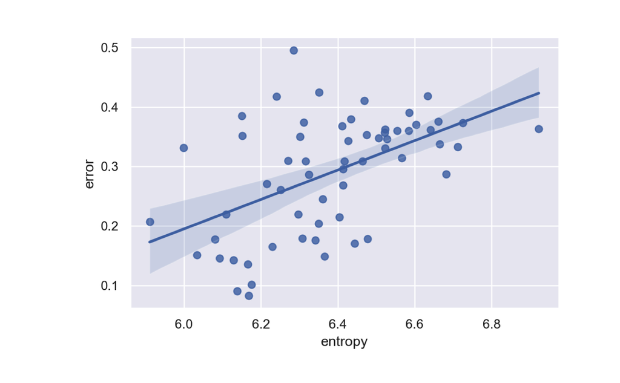

```python
reticulate::repl_python()
sns.lmplot(entropies, x="ngram_entropy", y="error")
plt.xlabel("entropy")
plt.tight_layout(pad=3)
plt.show()
plt.savefig("entropy_error.png")
plt.clf()
```

```r
quit
cor.test(py$entropies$ngram_entropy, py$entropies$error)
```

```
    Pearson's product-moment correlation

data:  py$entropies$ngram_entropy and py$entropies$error
t = 4.6133, df = 58, p-value = 2.235e-05
alternative hypothesis: true correlation is not equal to 0
95 percent confidence interval:
 0.3042039 0.6822722
sample estimates:
      cor
0.5181074
```